# Replication of Rheault & Cochrane (2020)

## STEP 3: Replicating the **US Congress** Analysis

#### Data Extraction from Word Embedding Model

This code extracts party embeddings from the pre-trained Doc2Vec model for the US House of Representatives. The model contains vector representations of political parties across different Congresses, with Democrats labeled as “D_[congress number]” and Republicans as “R_[congress number]”.

```python
from gensim.models import Doc2Vec
import pandas as pd
import os
import numpy as np

# Load the pre-trained model
model = Doc2Vec.load("models/house200")

# Extract party tags (D_ for Democrats, R_ for Republicans)
all_tags = list(model.docvecs.doctags.keys())
party_tags = [tag for tag in all_tags if str(tag).startswith(('D_', 'R_'))]
print(f"Found {len(party_tags)} party tags")
```

```
## Found 144 party tags
```

```python
# Extract embeddings for party tags
party_vectors = [model.docvecs[tag] for tag in party_tags]

# Create year mapping from congress numbers
tag_years = []
for tag in party_tags:
    tag_str = str(tag)
    parts = tag_str.split('_')
    if len(parts) > 1 and parts[1].isdigit():
        congress = int(parts[1])
        year = 1789 + (congress - 1) * 2  # Convert congress number to approximate year
        party = "Democrats" if parts[0] == "D" else "Republicans"
        tag_years.append({
            'tag': tag_str,
            'party': party,
            'congress': congress,
            'year': year
        })

# Save vectors and metadata to CSV files
os.makedirs('data', exist_ok=True)
party_df = pd.DataFrame(party_vectors, index=party_tags)
party_df.to_csv("data/us_house_vectors.csv")
pd.DataFrame(tag_years).to_csv("data/us_house_tag_years.csv", index=False)
print(f"Saved {len(party_vectors)} vectors and {len(tag_years)} tag-year mappings")
```

```
## Saved 144 vectors and 144 tag-year mappings
```

### Visualization of Party Placement (Figure 2)

This code creates Figure 2 from the paper, showing the ideological placement of US political parties over time. We uses Principal Component Analysis (PCA) to reduce the 200-dimensional embeddings to two dimensions.

The visualization consists of three panels:

1. a scatter plot showing the two-dimensional projection
2. a time series of the first dimension (left-right ideology)
3. a time series of the second dimension (South-North regional divide).

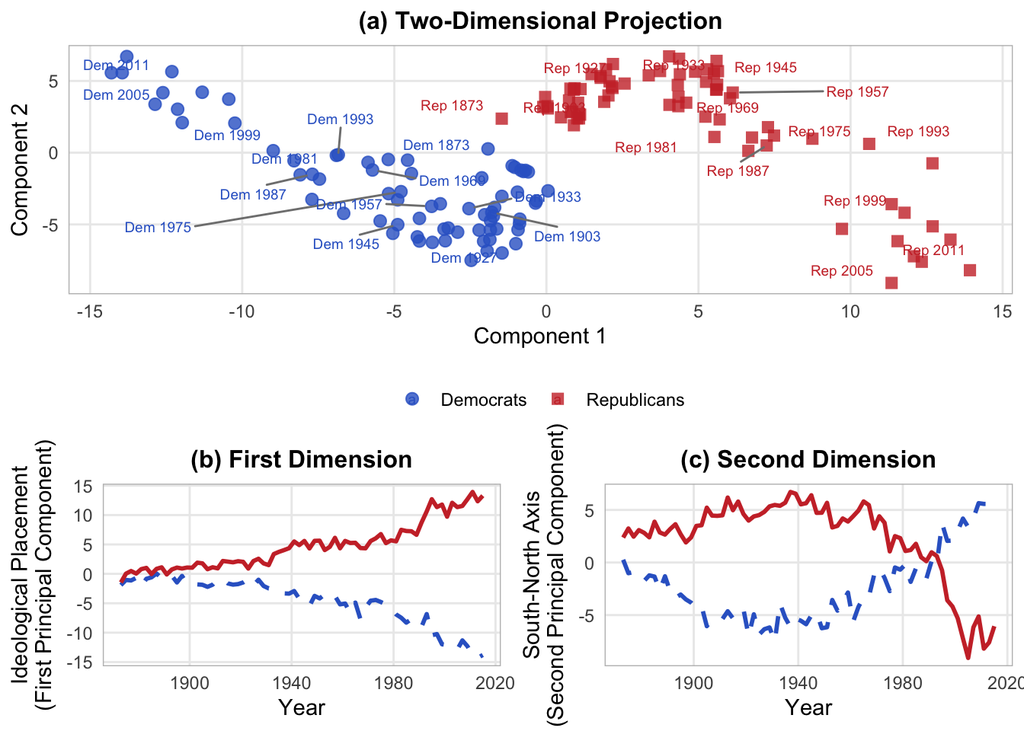

```r
library(readr)
library(dplyr)
library(ggplot2)
library(ggrepel)
library(gridExtra)
library(cowplot)
# Load the extracted embeddings and metadata
party_vectors <- read_csv("data/us_house_vectors.csv", show_col_types = FALSE)
tag_years <- read_csv("data/us_house_tag_years.csv", show_col_types = FALSE)

# Prepare data for PCA
mat <- as.matrix(party_vectors[,-1])
rownames(mat) <- party_vectors[[1]]

# Run PCA to reduce to two dimensions
pca <- prcomp(mat, scale. = TRUE)
pca_df <- data.frame(party_tag = rownames(mat), PC1 = pca$x[,1], PC2 = pca$x[,2])

# Join with year and party information
pca_df <- left_join(pca_df, tag_years, by = c("party_tag" = "tag"))

# Reorient axes to match conventional interpretation
# Democrats should be on the left (negative PC1)
if(mean(pca_df$PC1[pca_df$party == "Democrats"]) > mean(pca_df$PC1[pca_df$party == "Republicans"])) {
  pca_df$PC1 <- -pca_df$PC1
}

# For PC2, recent Democrats should be above Republicans (South-North orientation)
recent_dem <- pca_df %>% filter(party == "Democrats", year > 2000)
recent_rep <- pca_df %>% filter(party == "Republicans", year > 2000)
if(mean(recent_dem$PC2) < mean(recent_rep$PC2)) {
  pca_df$PC2 <- -pca_df$PC2
}

# Select key years to label in the plot
key_years <- c(1873, 1903, 1927, 1933, 1945, 1957, 1969, 1975, 1981, 1987, 1993, 1999, 2005, 2011)
label_points <- pca_df %>%
  filter(year %in% key_years) %>%
  mutate(label = paste0(substr(party, 1, 3), " ", year))

# Set visual attributes
party_colors <- c("Democrats" = "#3366CC", "Republicans" = "#CC3333")
party_shapes <- c("Democrats" = 19, "Republicans" = 15)

# Panel (a): Two-dimensional projection
p1 <- ggplot(pca_df, aes(x = PC1, y = PC2, color = party, shape = party)) +
  geom_point(size = 2.5, alpha = 0.8) +
  geom_text_repel(
    data = label_points,
    aes(label = label),
    size = 2.5,
    box.padding = 0.5,
    point.padding = 0.3,
    segment.color = "gray50",
    max.overlaps = 30
  ) +
  scale_color_manual(values = party_colors) +
  scale_shape_manual(values = party_shapes) +
  labs(
    title = "(a) Two-Dimensional Projection",
    x = "Component 1",
    y = "Component 2"
  ) +
  theme_minimal() +
  theme(
    legend.position = "bottom",
    legend.title = element_blank(),
    plot.title = element_text(face = "bold", size = 12, hjust = 0.5),
    panel.grid.minor = element_blank(),
    panel.border = element_rect(color = "gray", fill = NA, size = 0.5)
  )

# Create time series data
time_series <- pca_df %>%
  arrange(year) %>%
  group_by(party, year) %>%
  summarize(
    PC1 = mean(PC1),
    PC2 = mean(PC2),
    .groups = 'drop'
  )

# Panel (b): First dimension time series
p2 <- ggplot(time_series, aes(x = year, y = PC1, color = party, linetype = party)) +
  geom_line(linewidth = 1) +  # Updated from size to linewidth
  scale_color_manual(values = party_colors) +
  scale_linetype_manual(values = c("Democrats" = "dashed", "Republicans" = "solid")) +
  labs(
    title = "(b) First Dimension",
    x = "Year",
    y = "Ideological Placement\n(First Principal Component)"
  ) +
  theme_minimal() +
  theme(
    legend.position = "upper left",
    legend.title = element_blank(),
    plot.title = element_text(face = "bold", size = 12, hjust = 0.5),
    panel.grid.minor = element_blank(),
    panel.border = element_rect(color = "gray", fill = NA, size = 0.5)
  )

# Panel (c): Second dimension time series
p3 <- ggplot(time_series, aes(x = year, y = PC2, color = party, linetype = party)) +
  geom_line(linewidth = 1) +  # Updated from size to linewidth
  scale_color_manual(values = party_colors) +
  scale_linetype_manual(values = c("Democrats" = "dashed", "Republicans" = "solid")) +
  labs(
    title = "(c) Second Dimension",
    x = "Year",
    y = "South-North Axis\n(Second Principal Component)"
  ) +
  theme_minimal() +
  theme(
    legend.position = "lower right",
    legend.title = element_blank(),
    plot.title = element_text(face = "bold", size = 12, hjust = 0.5),
    panel.grid.minor = element_blank(),
    panel.border = element_rect(color = "gray", fill = NA, size = 0.5)
  )

# Use plot_grid from cowplot for better layout control
bottom_row <- plot_grid(p2, p3, ncol = 2, align = "h")
combined_plot <- plot_grid(p1, bottom_row, ncol = 1, rel_heights = c(1.5, 1))

combined_plot
```

```r
# Save the figure
ggsave("figures/figure2_us_house.pdf", combined_plot, width = 10, height = 12)
ggsave("figures/figure2_us_house.png", combined_plot, width = 10, height = 12, dpi = 300)
```

## STEP 4: Replicating the Validation Code

To replicate the validation process from the paper (Table 2), we need to correlate the **principal component scores** with **external benchmarks**.

#### Examine the benchmark data files

```r
# List all CSV files in the data directory
data_files <- list.files("data", pattern = "*.csv", full.names = TRUE)
data_files
```

```
##  [1] "data/can_polar.csv"                 "data/canada_parameterization.csv"
##  [3] "data/canada_party_vectors.csv"      "data/extreme_words_pc1.csv"
##  [5] "data/extreme_words_pc2.csv"         "data/goldstandard_canada.csv"
##  [7] "data/goldstandard_house.csv"        "data/goldstandard_senate.csv"
##  [9] "data/goldstandard_senate114.csv"    "data/goldstandard_uk.csv"
## [11] "data/house_parameterization.csv"    "data/house_party_vectors.csv"
## [13] "data/PC1_vector.csv"                "data/PC2_vector.csv"
## [15] "data/senate_parameterization.csv"   "data/twitter_user_vectors_pvdm.csv"
## [17] "data/twitter_user_vectors.csv"      "data/uk_parameterization.csv"
## [19] "data/uk_party_vectors.csv"          "data/uk_polar.csv"
## [21] "data/us_house_tag_years.csv"        "data/us_house_vectors.csv"
## [23] "data/us_polar.csv"                  "data/wf_full.csv"
## [25] "data/wf_short.csv"
```

```r
# From the file names, we can see several types:
#   - goldstandard_*.csv       <-- External validation measures
#   - *_parameterization.csv   <-- Parameter settings
#   - *_polar.csv              <-- Contains ideological positions

# Let's examine one file to understand its structure
# Examine the gold standard data for US House
gold_house <- read_csv("data/goldstandard_house.csv")
str(gold_house)
```

```
## spc_tbl_ [96 × 12] (S3: spec_tbl_df/tbl_df/tbl/data.frame)
##  $ party         : chr [1:96] "D" "D" "D" "D" ...
##  $ year          : num [1:96] 1921 1923 1925 1927 1929 ...
##  $ label         : chr [1:96] "Dem 1921" "Dem 1923" "Dem 1925" "Dem 1927" ...
##  $ congress      : num [1:96] 67 68 69 70 71 72 73 74 75 76 ...
##  $ voteview      : num [1:96] -0.31 -0.289 -0.281 -0.286 -0.284 ...
##  $ experts       : num [1:96] NA NA NA NA NA NA NA NA NA NA ...
##  $ experts_source: chr [1:96] NA NA NA NA ...
##  $ experts_n     : num [1:96] NA NA NA NA NA NA NA NA NA NA ...
##  $ experts_stand : num [1:96] NA NA NA NA NA NA NA NA NA NA ...
##  $ rile          : num [1:96] -9.92 NA -8.82 NA -13.09 ...
##  $ vanilla       : num [1:96] -5.23 NA -6.09 NA -5.73 ...
##  $ legacy        : num [1:96] -1.16 NA -2.67 NA -1.82 ...
##  - attr(*, "spec")=
##   .. cols(
##   ..   party = col_character(),
##   ..   year = col_double(),
##   ..   label = col_character(),
##   ..   congress = col_double(),
##   ..   voteview = col_double(),
##   ..   experts = col_double(),
##   ..   experts_source = col_character(),
##   ..   experts_n = col_double(),
##   ..   experts_stand = col_double(),
##   ..   rile = col_double(),
##   ..   vanilla = col_double(),
##   ..   legacy = col_double()
##   .. )
##  - attr(*, "problems")=<externalptr>
```

```r
head(gold_house)
```

```
## # A tibble: 6 × 12
##   party  year label    congress voteview experts experts_source experts_n
##   <chr> <dbl> <chr>       <dbl>    <dbl>   <dbl> <chr>              <dbl>
## 1 D      1921 Dem 1921       67   -0.310      NA <NA>                  NA
## 2 D      1923 Dem 1923       68   -0.289      NA <NA>                  NA
## 3 D      1925 Dem 1925       69   -0.281      NA <NA>                  NA
## 4 D      1927 Dem 1927       70   -0.286      NA <NA>                  NA
## 5 D      1929 Dem 1929       71   -0.284      NA <NA>                  NA
## 6 D      1931 Dem 1931       72   -0.256      NA <NA>                  NA
## # ℹ 4 more variables: experts_stand <dbl>, rile <dbl>, vanilla <dbl>,
## #   legacy <dbl>
```